# Trio PSD proteome analysis

Sameer Aryal Postdoctoral Associate Sheng Laboratory Broad Institute of MIT and Harvard

Oct. 9, 2020

How does genetically removing Trio alter the postsynaptic density (PSD) proteome? Examining TMT labeled PSD proteome from WT, Trio/+, and Trio/Trio mice. Experiment carried out by Borislav Dejanovic.

```r
# Load data and libraries
rm(list=ls())
require(readxl)
require(tidyverse)
require(tm)
require(ggfortify)
require(reshape2)
require(ggbeeswarm)
require(EnhancedVolcano)
require(RColorBrewer)
require(fgsea)
```

Loading data and helper functions.

```r
files.sources = list.files("../functions" , full.names = TRUE)
invisible(lapply(files.sources, source))
trio.xls <- read_xlsx("../data/results_PSD-Trio-proteome_Two-sample_mod_T_2020-07-24.xlsx")
```

```
-
/
```

```r
trio.xls <- trio.xls %>% drop_na(logFC.WT.over.KO)
```

Does the data have any underlying structure?

```r
trio.abundances <- trio.xls %>% dplyr::select(starts_with("Trio_PSD_TMT11_Proteome.."))
#Renaming columns for clarity
trio.sampleSheet <- makeSampleSheet(trio.abundances)
colnames(trio.abundances) <- trio.sampleSheet$cleanId
# Remove any rows with NA
trio.abundances.clean <- na.omit(trio.abundances)
trio.abundances.pca.plot <- makePcaPlot(trio.abundances.clean, trio.sampleSheet$color)
```

```
the condition has length > 1 and only the first element will be used
```

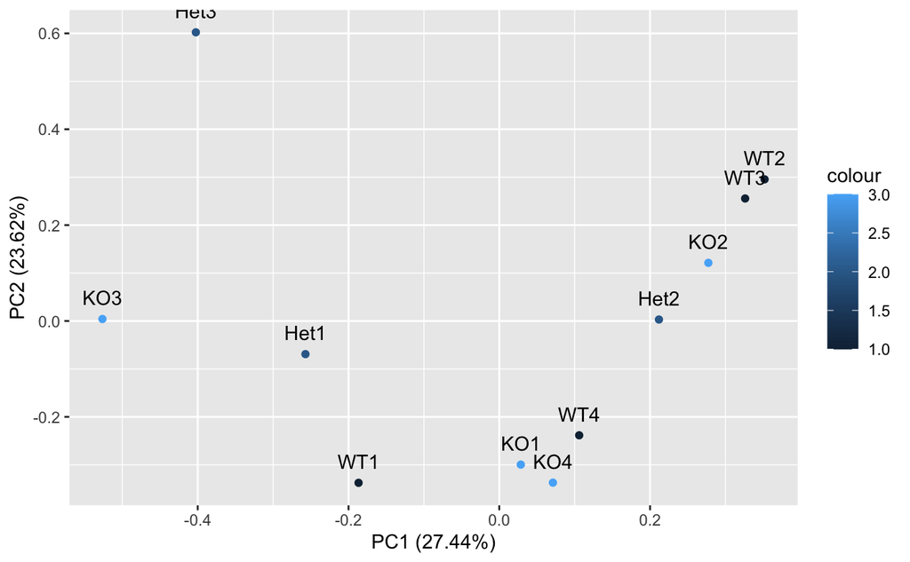

```r
trio.abundances.pca.plot
```

Does log transformation reveal any underlying structure?

```r
###
trio.abundances.clean.log <- log(trio.abundances.clean+abs(min(trio.abundances.clean))+1)
trio.abundances.clean.log.pca.plot <- makePcaPlot(trio.abundances.clean.log, trio.sampleSheet$color)
```

```
the condition has length > 1 and only the first element will be used
```

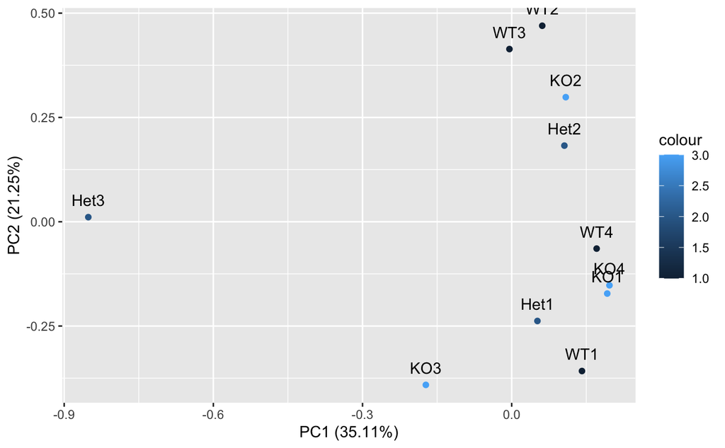

```r
trio.abundances.clean.log.pca.plot
```

```r
# No inherent structure in the data
# Samples do not vary primarily by genotype
```

How does expresssion of Trio vary with genotype?

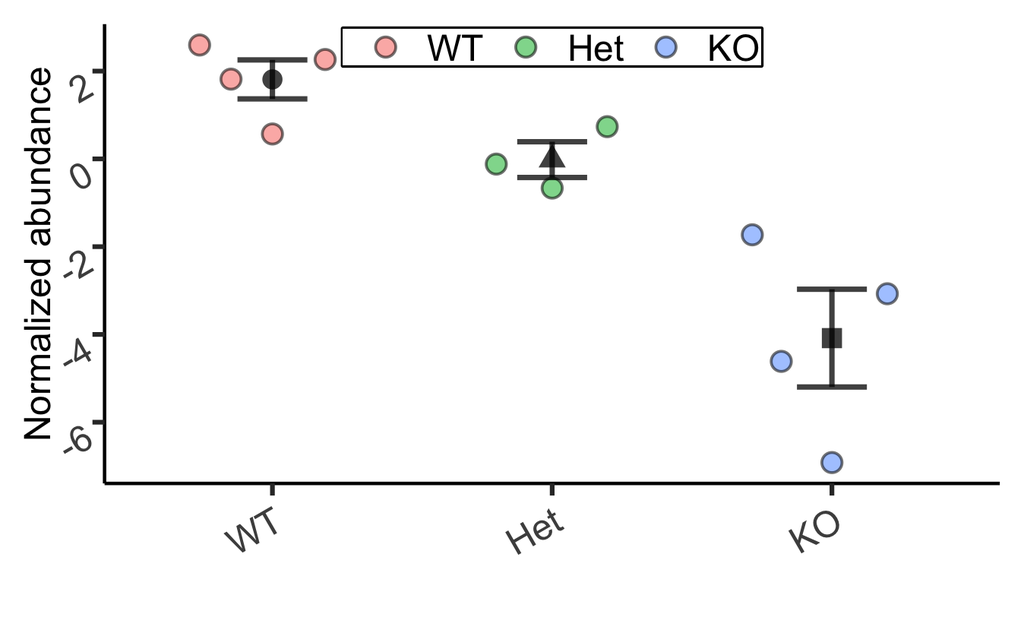

```r
# Check abundance of Trio protein
trio.trio.abundance.m <- getAbundanceOfProtein(trio.xls,
                                             'Q0KL02',
                                             "Trio_PSD_TMT11_Proteome..",
                                             trio.sampleSheet)
trio.trio.abundance.plot <- makeAbundancePlot(trio.trio.abundance.m)
trio.trio.abundance.plot
```

The Broad modeling (moderated t-test followed by FDR adjustment) finds that no genes, including Trio, are significantly altered after FDR adjustment of p-values. The following plot shows the distribution of FDR adjusted p-values.

[figure not shown]

I am therefore using nominal p-values for further analysis of the data. Here is how the nominal p-value distribution looks like.

```r
plot(density(trio.xls$P.Value.WT.over.KO), xlim=c(0,1))
```

[output not shown]

Since we are using nominal p-values, the chances of getting false positive hits is quite high. The number of proteins with p-values below 0.05 is:

```r
sum(trio.xls$P.Value.WT.over.KO < 0.05)
```

[output not shown]

Which proteins are the most consistently altered across replicates? Plotting LFC(KO/WT) against nominal p-value.

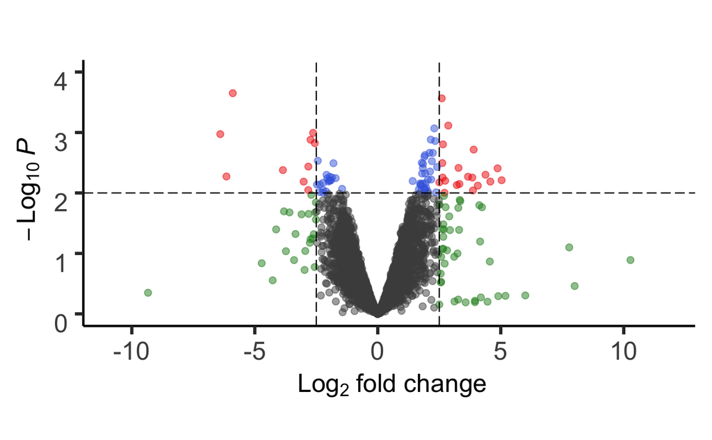

```r
#Plotting FDR adjusted p value against LFC
trio.xls <- trio.xls %>% dplyr::mutate(logFC.KO.over.WT = logFC.WT.over.KO*(-1))
vPlot <- makeVolcanoPlot(trio.xls)
vPlot
```

Labeling the genes that Borislav has picked out for further confirmation and has validated antibodies for.

[figure not shown]

```r
borislavLabels <- c("Trio", "Grin1", "Nrcam", "Dlgap1", "Clu", "Prrt1", "Zdhhc5", "Nono", "Cers6", "Uba52", "Rpl29")
vPlot2 <- makeVolcanoPlot(trio.xls, borislavLabels)
vPlot2
```

Does the MW of the protein dictate its LFC? To examine this, I divided all proteins into 6 color coded bins. The bins are unequal in size, so that I can see any representative effects at extremes. Bin 1 harbors the proteins with the smallest MW, bin 6 the largest MWs.

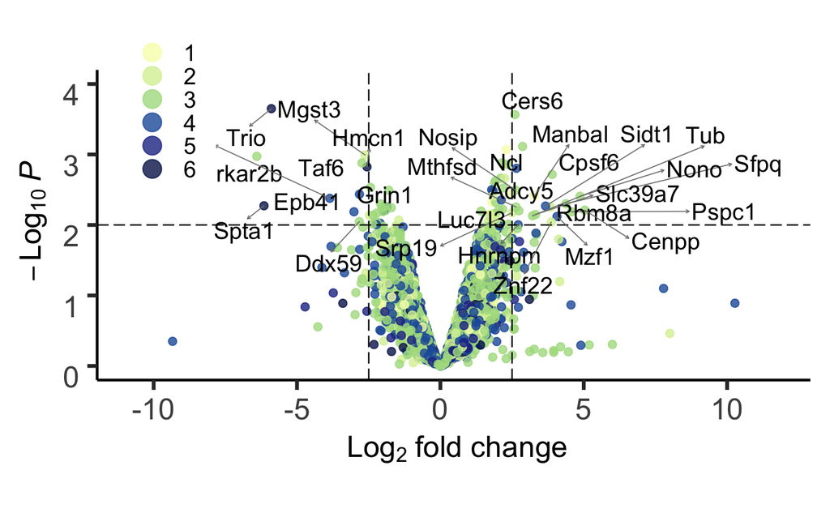

```r
trio.xls <- trio.xls %>% dplyr::mutate(log_protein_mw = log(protein_mw))
trio.xls <- setupBins(trio.xls, "log_protein_mw", c(0,9.5,10.25,11.25,12,12.5,16))
keyvals <- colorizeBins(trio.xls)
vPlot3 <- makeVolcanoPlot(trio.xls, NULL, 0.8, keyvals, c(0.1,0.9))
vPlot3
```

It does not look like the MW is associated with LFC. To examine this more systematically, I am using the same bins and plotting the cumulative frequency vs. LFC in each bin.

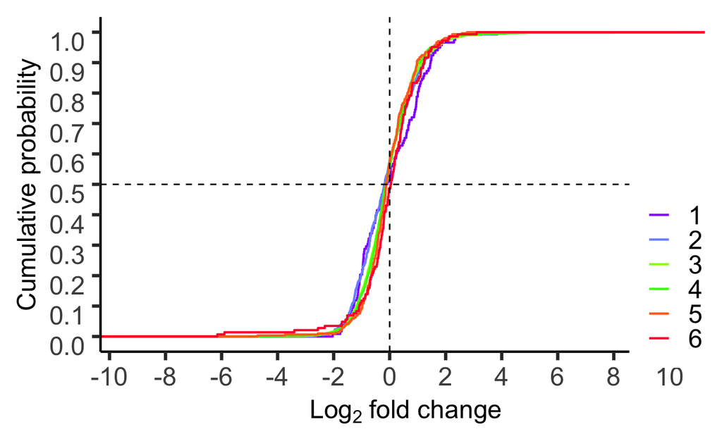

```r
#Stratify cumulative frequency by protein MW
lfcCumFreqPlot <- makeStratifiedCumLfcPlot(trio.xls)
lfcCumFreqPlot
```

In each bin, proteins are as likely to upregulated as they are to be downregulated. Therefore, the MW of a protein does not dictate its LFC. Neither large nor small proteins aren't especially overabundant in Trio KO mice.

MW is related but not wholly representative of the number of amino acids in a protein. Are the alterations in protein expression at the PSD with deletion of Trio associated with the number of amino acids in the protein (the protein length)?

```r
#Stratify by CDS length
geneLengths <- read.csv("~/bioChem/S3.genes.results", sep="\t", header=T)
geneLengths <- geneLengths[,c(1:3)]
resLen <- inner_join(trio.xls, geneLengths, by=c("geneSymbol"="gene_id"))
resLen$aaSize <- resLen$length/3
resLen$logAAsize <- log2(resLen$aaSize)
resLen <- setupBins(resLen, "logAAsize", c(0,6.5,7.5,9,10.5,12,16))
keyvals <- colorizeBins(resLen)
vPlot4 <- makeVolcanoPlot(resLen, NULL, 0.8, keyvals, c(0.1,0.9))
vPlot4
```

[output not shown]

It does not look like LFC is dependent on protein length either. Analysing this more systematically now.

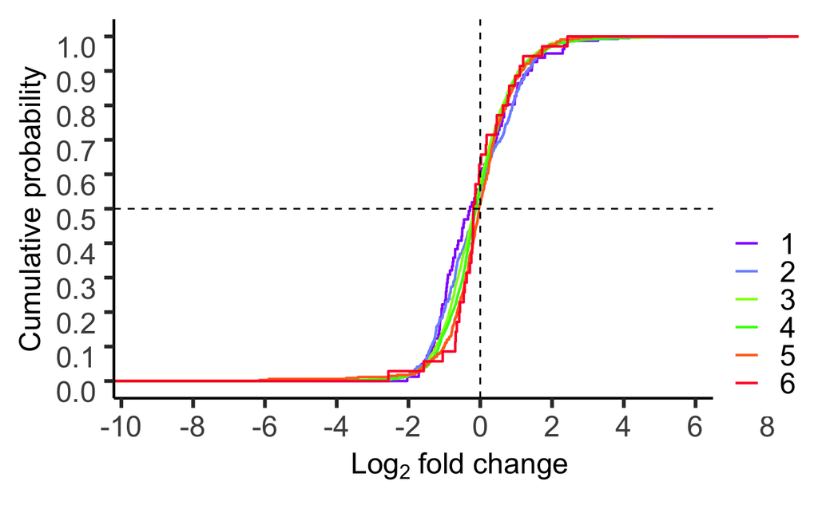

```r
# Lfcbins has changed now. Stratifying LFC cum freq w/ CDS length bins.
lfcCumFreqPlot <- makeStratifiedCumLfcPlot(resLen)
lfcCumFreqPlot
```

We can conclude that protein length is not associated with alteration in protein expression.

Carrying out Gene Set Enrichment Analysis now.

```r
# Gene ontology analysis
trio.xls <- trio.xls %>% mutate(t.KO.over.WT = t.WT.over.KO*(-1))
goPathways <- "~/Google Drive/seqTables/geneSets/c5.all.v7.0.symbols.gmt"
trio.go <- doGoAnalysis(trio.xls, goPathways)
trio.go$up
trio.go$down
```

[output not shown]

```r
trio.trio.abundance.m <- getAbundanceOfProtein(trio.xls,
                                             'Q9CZR3',
                                             "Trio_PSD_TMT11_Proteome..",
                                             trio.sampleSheet)
trio.trio.abundance.plot <- makeAbundancePlot(trio.trio.abundance.m)
trio.trio.abundance.plot
```

[output not shown]